# 6306: Week 4 FLS

Matt Farrow

9/12/2020

## Baltimore Restaurant Data

You have been hired by a restaurateur to some research on Sushi restaurants in Baltimore. You have come across data on the web contained in the following XML [file](https://d396qusza40orc.cloudfront.net/getdata%2Fdata%2Frestaurants.xml).

### Scrape the XML page for name, zip code and city council district. (Use either the XML or rvest package.)

```r
# Read data
baltimore <- read_html("https://d396qusza40orc.cloudfront.net/getdata%2Fdata%2Frestaurants.xml")

# Names
baltimore_names <- html_nodes(baltimore, "name")
baltimore_names <- str_sub(baltimore_names, start = 7, end = -8)

# Zip codes
baltimore_zip <- html_nodes(baltimore, "zipcode")
baltimore_zip <- as.numeric(str_sub(baltimore_zip, 10, -11))

# Council districts
baltimore_council <- html_nodes(baltimore, "councildistrict")
baltimore_council <- as.numeric(str_sub(baltimore_council, 18, -19))
```

### Make a data frame with just those columns.

```r
# Make tibble
restaurants <- tibble(name = baltimore_names,
                      zip_code = baltimore_zip,
                      council_district = baltimore_council)

# Look at tibble
glimpse(restaurants)
```

```
## Rows: 1,327
## Columns: 3
## $ name             <chr> "410", "1919", "SAUTE", "#1 CHINESE KITCHEN", "#1 ch…
## $ zip_code         <dbl> 21206, 21231, 21224, 21211, 21223, 21218, 21205, 212…
## $ council_district <dbl> 2, 1, 1, 14, 9, 14, 13, 7, 13, 1, 10, 5, 1, 1, 11, 1…
```

### Are there any Sushi restaurants in Baltimore? If so, can you estimate how many?

```r
sushi <- restaurants %>%
  filter(name %in% str_subset(restaurants$name, regex("sushi", ignore_case = TRUE)))

sushi %>%
  gt() %>%
  tab_header(title = "Sushi Restaurants in Baltimore") %>%
  cols_label(name = "Restaurant Name",
             zip_code = "Zip",
             council_district = "Council District")
```

Sushi Restaurants in Baltimore

| Restaurant Name | Zip | Council District |
| --- | --- | --- |
| ABC SUSHI | 21205 | 13 |
| ASAHI SUSHI | 21231 | 1 |
| CHIU'S SUSHI JAPANESE RESTAURANT | 21202 | 1 |
| CHIYO SUSHI | 21209 | 5 |
| EDO SUSHI | 21202 | 11 |
| GENJI SUSHI EXPRESS (A.K.A. 600 S EXETER ST) | 21202 | 1 |
| RA SUSHI | 21231 | 1 |
| KIKU SUSHI RESTAURANT | 21230 | 10 |
| SUSHI-SAN RESTAURANT | 21224 | 1 |

### Filter the data frame for just downtown restaurants (Council District 11). Are there any Sushi restaurants downtown? If so, estimate how many “Sushi” restaurants are in Downtown

```r
sushi %>%
  filter(council_district == 11) %>%
    gt() %>%
  tab_header(title = "Sushi Restaurants in Downtown Baltimore") %>%
  cols_label(name = "Restaurant Name",
             zip_code = "Zip",
             council_district = "Council District")
```

Sushi Restaurants in Downtown Baltimore

| Restaurant Name | Zip | Council District |
| --- | --- | --- |
| EDO SUSHI | 21202 | 11 |

### Make a bar plot of the estimated number of restaurants (Sushi or otherwise) in each council.

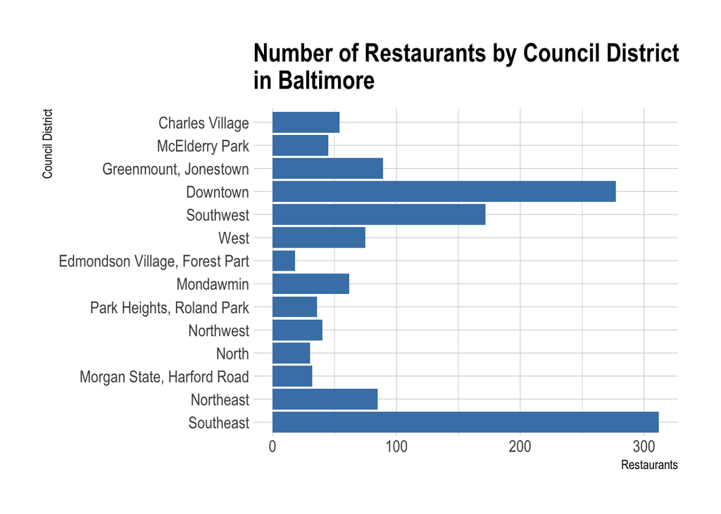

```r
restaurants %>%
  count(locale) %>%
  ggplot(aes(n, locale)) +
  geom_col(fill = "steelblue") +
  labs(title = "Number of Restaurants by Council District\nin Baltimore",
       x = "Restaurants",
       y = "Council District") +
  theme_ipsum()
```

## Freestyle

1. Install and load one of the packages given in the list for downloading APIs (or another API you have found and are interested in).
2. Download data from that API and create a slide that clearly describes the package and how (the code) to download data from that API.
3. Clearly describe the data and the columns / variables that are of interest to your presentation.
4. Perform a small EDA with your data. Use plots and possibly tests, to find 2 interesting characteristics of the data that you accessed through the API.
5. Create a PPT presentation to show in the live session.
6. Show part or all of the data and make sure to show the data are tidy.
7. Include at least 1 plot or chart from ggplot.
8. You should have no more than five slides (including the title slide).
9. Include your code.

Also include a discussion of any obstacles you ran into and went around or over in the process… there will inevitably be one and likely more.

### Set Up Secrets & Twitter Authentication

Here I’m using the `secret` package to securely store my API keys so they’re not in plaintext in my code. Since I sync my files up to GitHub, I didn’t want to have those publicly available. I also ended up using the `rtweet` package instead of the `twitteR` package.

```r
library(secret)
library(rtweet)
# Set up secrets
my_vault <- here::here("static", "data", "secret-vault.vault")
mattfarrow_private_key <- file.path("~", "r_vault")

# Get Twitter API keys
twitter_api_key <-
  get_secret("twitter_api_key", key = mattfarrow_private_key, vault = my_vault)
twitter_api_secret_key <-
  get_secret("twitter_api_secret_key", key = mattfarrow_private_key, vault = my_vault)
twitter_access_token <-
  get_secret("twitter_access_token", key = mattfarrow_private_key, vault = my_vault)
twitter_access_token_secret <-
  get_secret("twitter_access_token_secret", key = mattfarrow_private_key, vault = my_vault)

# Setup Twitter access
create_token(
  app = "DataScience@SMU",
  consumer_key = twitter_api_key,
  consumer_secret = twitter_api_secret_key,
  access_token = twitter_access_token,
  access_secret = twitter_access_token_secret,
  set_renv = TRUE
)
```

```
## <Token>
## <oauth_endpoint>
##  request:   https://api.twitter.com/oauth/request_token
##  authorize: https://api.twitter.com/oauth/authenticate
##  access:    https://api.twitter.com/oauth/access_token
## <oauth_app> DataScience@SMU
##   key:    S6285Oca0xyp5IR1gZoygBnEF
##   secret: <hidden>
## <credentials> oauth_token, oauth_token_secret
## ---
```

### Visualizing a Graph of Retweet Relationships

Using the Twitter API, I thought I’d try my hand at visualizing a grph of retweet relationships using an example from [Bob Rudis](https://rud.is/books/21-recipes/visualizing-a-graph-of-retweet-relationships.html.

```r
library(igraph)
library(ggraph)

# Search for #rstats tweets
rstats <- search_tweets("#rstats", n=1500)

# Look at the data
glimpse(rstats)
```

```
## Rows: 1,021
## Columns: 90
## $ user_id                 <chr> "210555477", "249889366", "890283198588092420…
## $ status_id               <chr> "1304957875899584512", "1304957662862417920",…
## $ created_at              <dttm> 2020-09-13 01:39:37, 2020-09-13 01:38:46, 20…
## $ screen_name             <chr> "v_braun", "CronusMaster", "TalkR_ES", "nlogn…
## $ text                    <chr> "Tell some more combination \U0001f923\n\n#Py…
## $ source                  <chr> "vbr-tweet-app", "Twitter Web App", "TalkR_ES…
## $ display_text_width      <dbl> 140, 121, 140, 140, 140, 139, 140, 139, 139, …
## $ reply_to_status_id      <chr> NA, NA, NA, NA, NA, NA, NA, NA, NA, NA, NA, N…
## $ reply_to_user_id        <chr> NA, NA, NA, NA, NA, NA, NA, NA, NA, NA, NA, N…
## $ reply_to_screen_name    <chr> NA, NA, NA, NA, NA, NA, NA, NA, NA, NA, NA, N…
## $ is_quote                <lgl> FALSE, FALSE, FALSE, FALSE, FALSE, FALSE, FAL…
## $ is_retweet              <lgl> TRUE, TRUE, TRUE, TRUE, TRUE, TRUE, TRUE, TRU…
## $ favorite_count          <int> 0, 0, 0, 0, 0, 0, 0, 0, 0, 0, 0, 0, 0, 0, 0, …
```

[output cut: 77 more lines]

```r
# Find the retweets (using the API-provided data) & expand out all the mentioned
# screen names
rt_g <- rstats %>%
  filter(retweet_count > 0) %>%
  select(screen_name, mentions_screen_name) %>%
  unnest(mentions_screen_name) %>%
  filter(!is.na(mentions_screen_name)) %>%
  graph_from_data_frame()

V(rt_g)$node_label <- unname(ifelse(degree(rt_g)[V(rt_g)] > 30, names(V(rt_g)), ""))
V(rt_g)$node_size <- unname(ifelse(degree(rt_g)[V(rt_g)] > 30, degree(rt_g), 0))
```

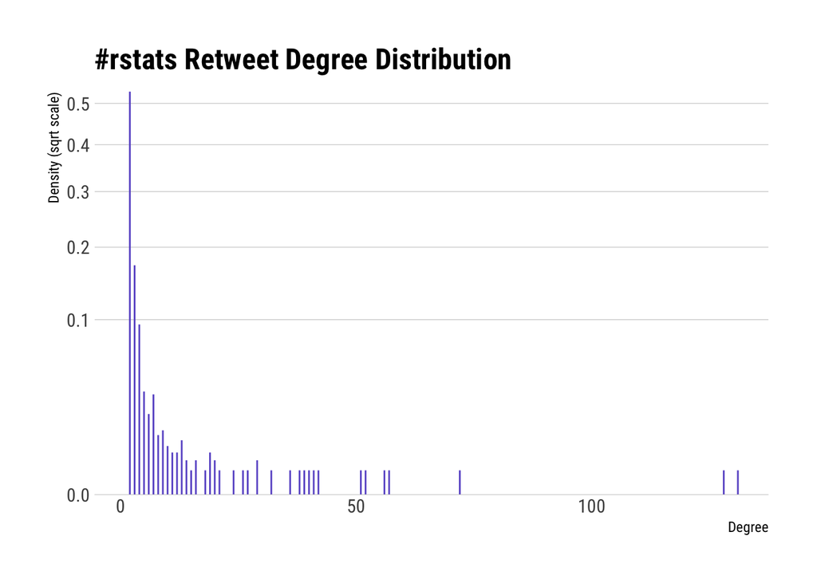

```r
ggplot(tibble(y = degree_distribution(rt_g), x = 1:length(y))) +
  geom_segment(aes(x, y, xend = x, yend = 0), color = "slateblue") +
  scale_y_continuous(expand = c(0, 0), trans = "sqrt") +
  labs(x = "Degree", y = "Density (sqrt scale)", title = "#rstats Retweet Degree Distribution") +
  theme_ipsum_rc(grid = "Y", axis = "x")
```

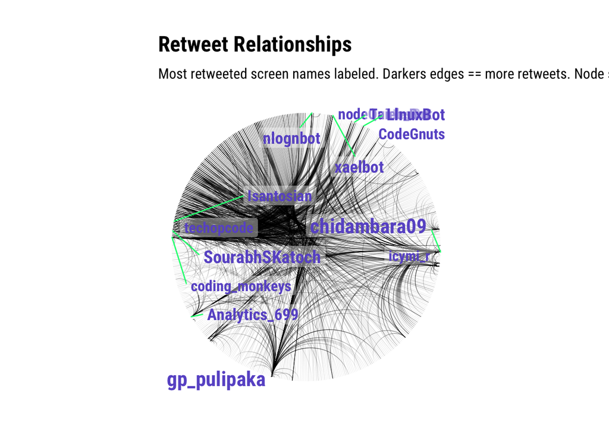

```r
ggraph(rt_g, layout = "linear", circular = TRUE) +
  geom_edge_arc(edge_width = 0.125, aes(alpha = ..index..)) +
  geom_node_label(aes(label = node_label, size = node_size),
    label.size = 0, fill = "#ffffff66", segment.colour = "springgreen",
    color = "slateblue", repel = TRUE, family = font_rc, fontface = "bold"
  ) +
  coord_fixed() +
  scale_size_area(trans = "sqrt") +
  labs(title = "Retweet Relationships", subtitle = "Most retweeted screen names labeled. Darkers edges == more retweets. Node size == larger degree") +
  theme_graph(base_family = font_rc) +
  theme(legend.position = "none")
```

The biggest obstacle I ran into was in trying to set up the `secrets` package in R. It was a bit of a challenge to translate the vignettes I found online into a working solution, and was exacerbated by my trying to put something in parenthases that shouldn’t have been, but I figured it out in the end.